# PracaDomowa02

Grzegorz Zbrzeżny

28 10 2021

# Wizualizacja do poprawienia

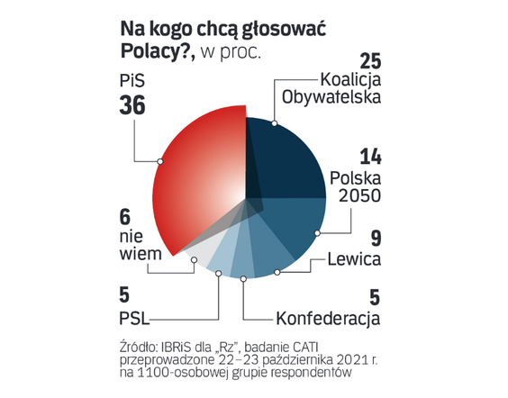

Wziąłem ją ze strony pod linkiem:  
https://www.rp.pl/polityka/art19043381-sondaz-ibris-dla-rzeczpospolitej-poparcie-wzroslo-wszystkim-tylko-nie-konfederacji-i-psl

Aby poprawić widoczny powyżej wykres, skorzystam z danych:

```r
Partie <- c("PiS", "KO", "Polska 2050",
            "Lewica", "Konfederacja", "PSL", "nie wiem")
Procenty <- c(36, 25, 14, 9, 5, 5, 6)

sondazData <- data.frame(Partie, Procenty)
sondazData
```

```
##         Partie Procenty
## 1          PiS       36
## 2           KO       25
## 3  Polska 2050       14
## 4       Lewica        9
## 5 Konfederacja        5
## 6          PSL        5
## 7     nie wiem        6
```

# Poprawiona wizualizacja

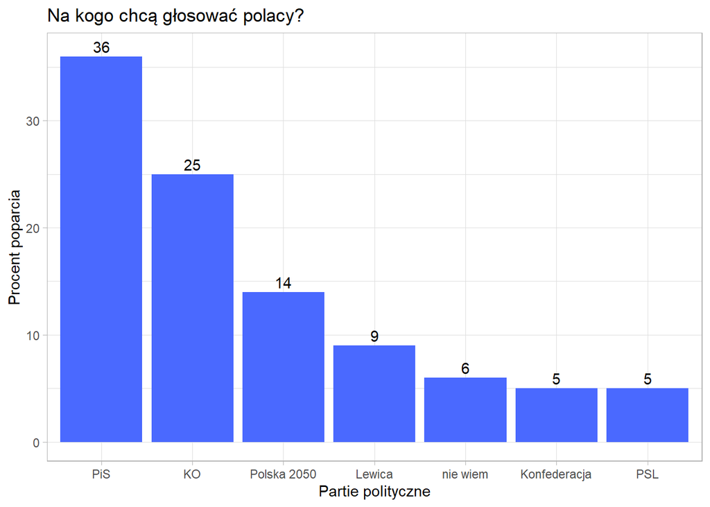

```r
sondazData %>% ggplot(aes(x = reorder(Partie, -Procenty), y = Procenty)) +
  geom_bar(stat="identity", fill="#4A69FF") +
  geom_text(aes(label=Procenty), vjust=0, nudge_y = .4,) +
  ggtitle("Na kogo chcą głosować polacy?") +
  xlab("Partie polityczne") + ylab("Procent poparcia") + theme_light()
```

Zrobiony przeze mnie wykres jest lepszy od oryginalnego, ponieważ:  
1. zastosowałem wykres słupkowy, na którym lepiej widać różnice w procentach niż na wykresie kołowym, zwłaszcza przy mało różniących się wynikach 2. na wykresie kołowym zastosowano nieczytelną skalę koloróW, na której najmniej popularne partie były ledwo widoczne, a u mnie każda partia ma jednakowy kolor i ilość procentóW ilustrują jedynie wysokości słupków, co powinno być czytelniejsze,  
3. partia, która zwyciężyła w sondażu została pokolorowana na kolor czerwony, który nijak ma się do skali zastosowanej do reszty. Ponadto kolor ten może się kojarzyć z czymś negatywnym, a sondaże powinny być obiektywne. To kolejny powód dla którego postanowiłem pokolorować wszystkie partie na jedną barwę,  
4. w części wykresu przeznaczonej dla zwycięskiej partii zastosowano efekt 3D, który również burzy czytelność wykresu, dlatego postanowiłem go usunąć,  
5. etykiety na oryginalnym wykresie były stworzone w sposób chaotyczny, na wykresie słupkowym są one uporządkowane.